# KF-summaries

Kevin Robb

9/8/2020

# Summary of Kalman Filter

## Introduction & Terms

I wrote this while going through the tutorial at kalmanfilter.net.

A *Kalman Filter* is a mathematical model which uses measurements and estimations (as well as the uncertainty in each) to produce accurate guesses of hidden variables which can include position, velocity, temperature, or whatever is being measured. The *KF* can be used in a wide variety of applications, and this tutorial focuses on target tracking as the primary example. This involves simple position measurements of an airplane moving linearly either towards or away from the sensor. Some other examples discussed are determining the temperature of a fish tank or the weight of something on a scale using many repeated measurements. The original paper by Rudolf Kalman was published in 1960 and described a recursive solution to the discrete-data linear filtering problem.

A *KF* works by using a set of five equations, each serving a purpose as follows in this section. These equations together with continued input from sensors produce a fairly accurate estimate of the current state of the system as well as a prediction of the *System State* at the next timestep. These future predictions are also used to take the next measurement (like making sure the radar hits the plane) and continue the *KF* process. As such, there is a requirement to have a prediction algorithm, called a *Dynamic Model*. For tracking a moving object, this can simply involve Newton’s equations of motion. The *Dynamic Model* (or *State Space Model*) takes the current state as input and gives the predicted next state as output.

Uncertainty in the sensor data is called *Measurement Noise*, and uncertainty in the *Dynamic Model* (due to not accounting for wind, turbulence, etc) is called *Process Noise*. The *Kalman Filter* is a prediction algorithm which takes into account both of these forms of noise in addition to the simple *Dynamic Model*. The *Kalman Filter* assumes normal distribution of measurement errors. The normal distribution (or Gaussian) is described by the probability density function (PDF):
$$f(x;\mu,\sigma^2)=\frac{1}{\sqrt{2 \pi \sigma^2}}e^{\frac{-(x-\mu)^2}{2 \sigma^2}}$$

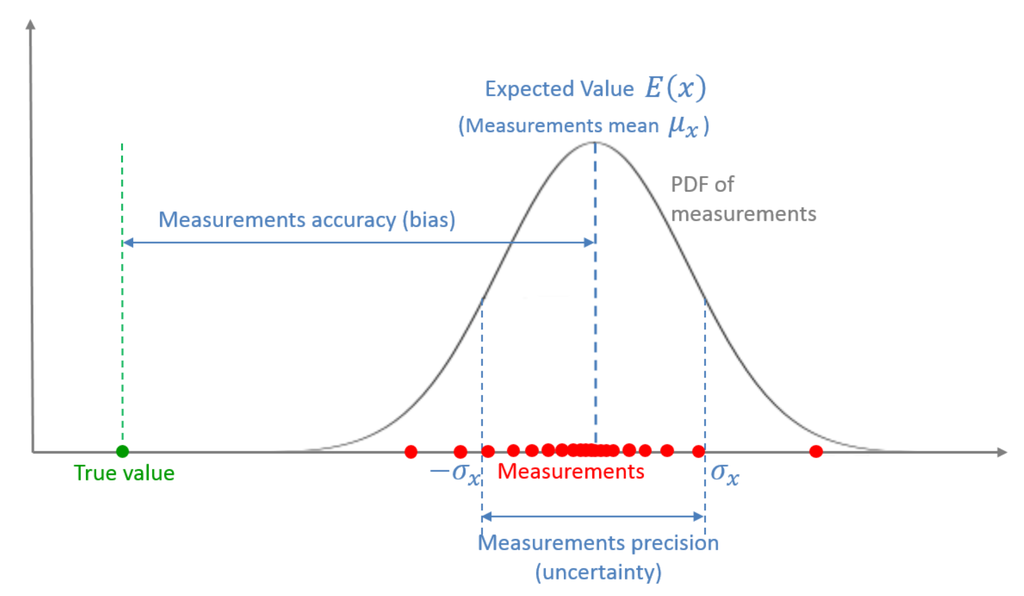

## Simple Example and the State Update Equation

This example features measuring the weight of a gold bar several times with a scale, and using these measurements to estimate the actual weight of the gold bar (assuming there is no systematic bias in the scale). The *Dynamic Model* here is very simple, since we expect the weight of the gold bar to stay constant.

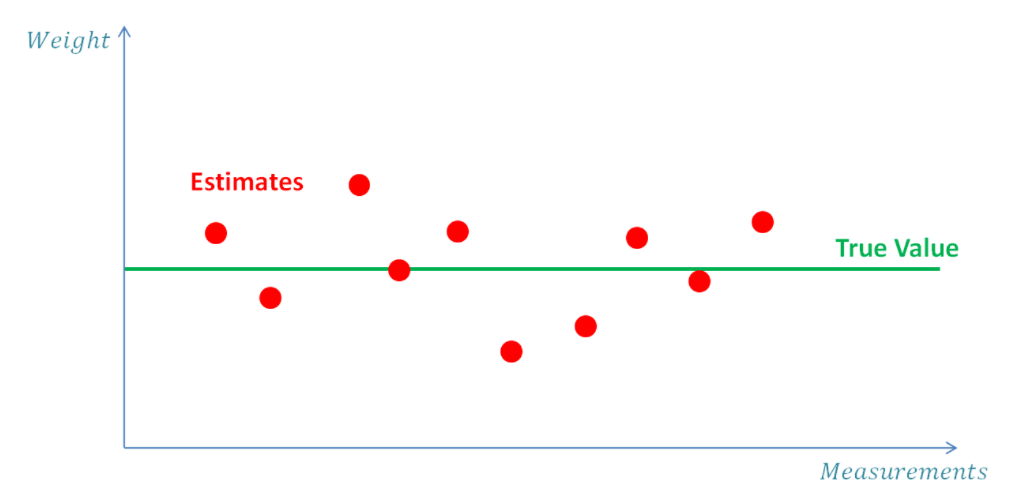

*Example set of measurements, with true value constant.*

We could find the true value by taking many measurements and averaging them, so we use this fact for our estimations.

$$\hat{x}_{N,N} = \frac{1}{N}(z_1 + z_2 + ... + z_N) = \frac{1}{N} \sum^N_{n=1}(z_n) \textrm{ ,}$$
where:

- $x$ is the true weight value (which we have no way of knowing exactly)
- $x_{n+1,n} = x_{n,n}$, because the dynamic model is constant.
- $z_n$ is the measurement at timestep $n$
- $\hat{x}_{n,n}$ is the estimate of $x$ made at timestep $n$ after taking the measurement $z_n$
- $\hat{x}_{n,n-1}$ is the previous estimate made at timestep $n-1$ after taking the measurement $z_{n-1}$
- $\hat{x}_{n+1,n}$ is the estimate of the next state made at timestep $n$ after taking the measurement $z_n$. This is a predicted state.

Our estimate for $x$ will build on all previous estimates, slowly converging towards the true value. Rather than keeping track of all previous measurements, we will simply use the most recent estimate and the current measurement. We can derive the equation
$$\hat{x}_{N,N} = \hat{x}_{N,N-1} + \frac{1}{N}(z_N - \hat{x}_{N,N-1}) \textrm{ ,}$$
which is called the *State Update Equation*. This is one of the five KF equations. The term $(z_N - \hat{x}_{N,N-1})$ is a measurement residual called the *innovation* which contains the new information.

The factor $\frac{1}{N}$ changes with each iteration, and is called the *Kalman Gain*. It is denoted $K_n$. We can rewrite the *State Update Equation* as
$$\hat{x}_{N,N} = (K_N) z_N + (1 - K_N) \hat{x}_{N,N-1} \textrm{ .}$$
The *Kalman Gain* will not always be in this form, but here it means that after $n$ becomes large enough, the measurement term is negligible and we can stop.

This process follows the procedure described in the following flow chart:

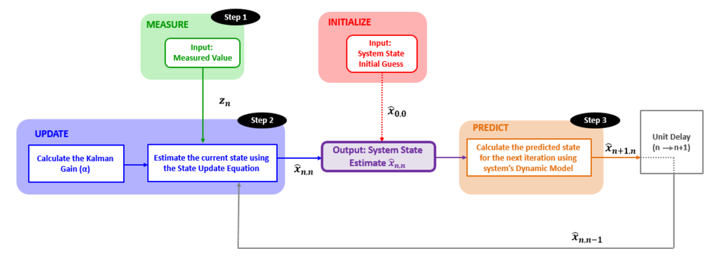

*Process followed as the Kalman Filter runs.*

An initial estimate is required to kick off the KF process, but it need not be very precise. Following this procedure yields something like the following:

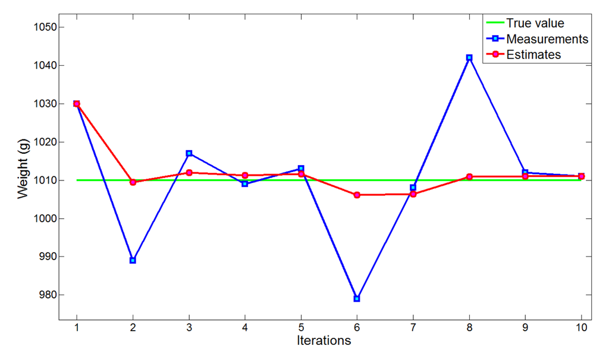

*Results of running the KF for ten timesteps.*

### Side Note

The *State Update Equation* is very similar to something I used in my research project in 2018. The agents in my population would evolve their *Learning Rate*, $L$, over the course of generations, and use this as the *Kalman Gain* in this general form to update their expected values for the rewards of each of the three possible choices. Similarly, it took into account the most recent reward and the aggregate expected reward, just as above

## Non-Constant Example and the State Extrapolation Equation

This example features an airplane moving horizontally at constant velocity away from a range detector. The *Dynamic Model* for this situation is no longer constant, and requires two equations of motion:
$$x_{n+1} = x_n + \dot{x}_n \Delta t \\
\dot{x}_{n+1} = \dot{x}_n$$
where $\Delta t$ is the interval between measurements, and $\dot{x}_n$ is the velocity at timestep $n$. This system of equations making up the *Dynamic Model* is called a *State Extrapolation Equation* (or *Transition Equation* / *Prediction Equation*), and is the second of the five *Kalman Filter* equations. This is because it extrapolates the current state to the next state as a prediction. Note that in this case there are two equations needed because we must predict the change in both the position and the velocity. Note that this example assumes our radar measures range and uses that to calculate velocity, rather than measuring velocity directly.

### The $\alpha$ - $\beta$ Filter

This is very similar to the previous example, but we have two equations and two variables to predict which form the *State Update Equation* for this example. These are also called the *$\alpha$ - $\beta$ track update equations.*

$$\hat{\dot{x}}_{n,n} = \hat{\dot{x}}_{n,n-1} + \beta (\frac{z_n - \hat{x}_{n,n-1}}{\Delta t}) \\
\hat{x}_{n,n} = \hat{x}_{n,n-1} + \alpha (z_n - \hat{x}_{n,n-1})$$
Here $\beta$ represents whether we think a difference between expectation and measurement was caused by radar imprecision or a change in the velocity of the aircraft. A much higher difference than we’d expect given the radar precision would elicit a high $\beta$, allowing our predicted velocity to change. If the difference is below our radar precision threshold, then we set a low $\beta$ since the velocity probably hasn’t changed, and the difference can be attributed to radar measurement error.

The value of $\alpha \in [0,1]$ is a set value that depends on our radar measurement precision (high $\alpha$ for high precision). Unlike the *Kalman Gain* in the basic *State Update Equation* in our first example, $\alpha$ does not change as the number of timesteps increases.

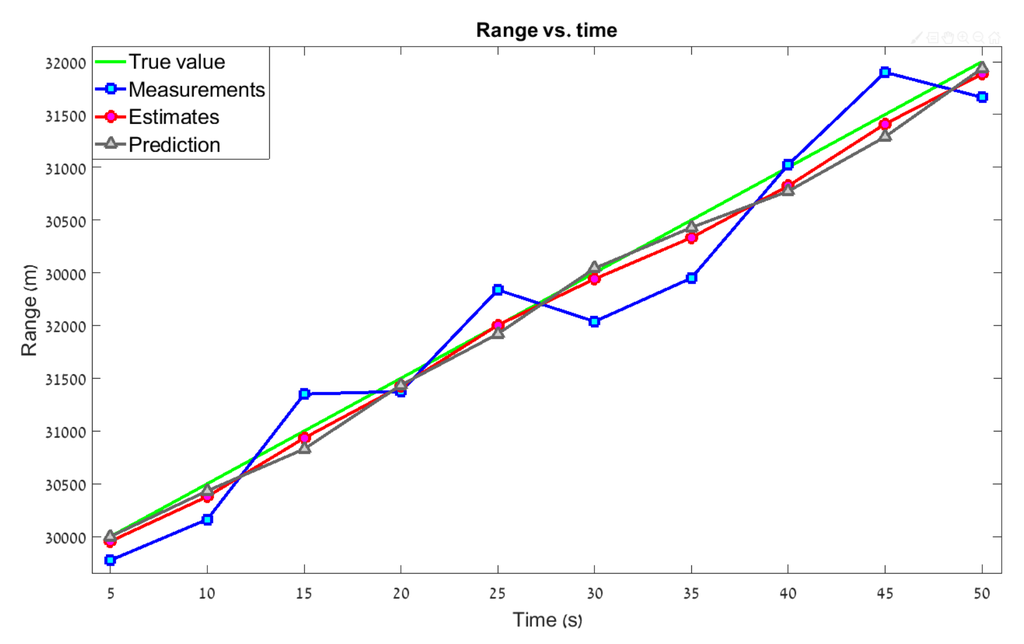

*Results of the $\alpha$ - $\beta$ filter. The estimates converge towards the true value*

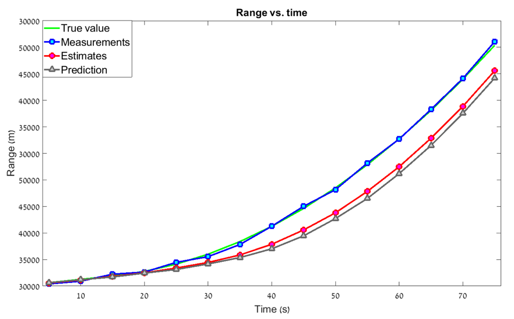

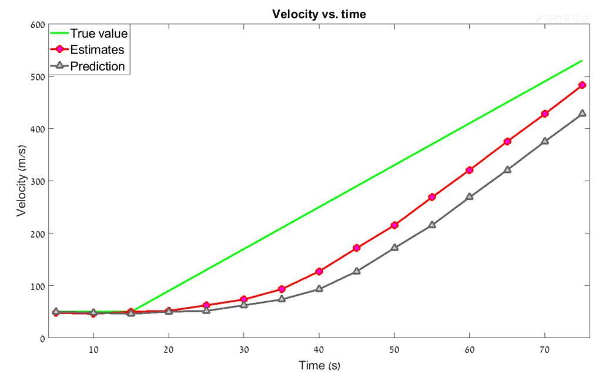

Estimates for range and velocity over many timesteps.

### The $\alpha$ - $\beta$ - $\gamma$ Filter

The addition of the $\gamma$ term essentially allows more equations to be used. We increase our *Dynamic Model* to three kinematic equations, accounting now for acceleration in addition to position and velocity. The *State Update Equation* then includes three equations, one for each coefficient. This process follows the previous very similarly, with the following graphical results:

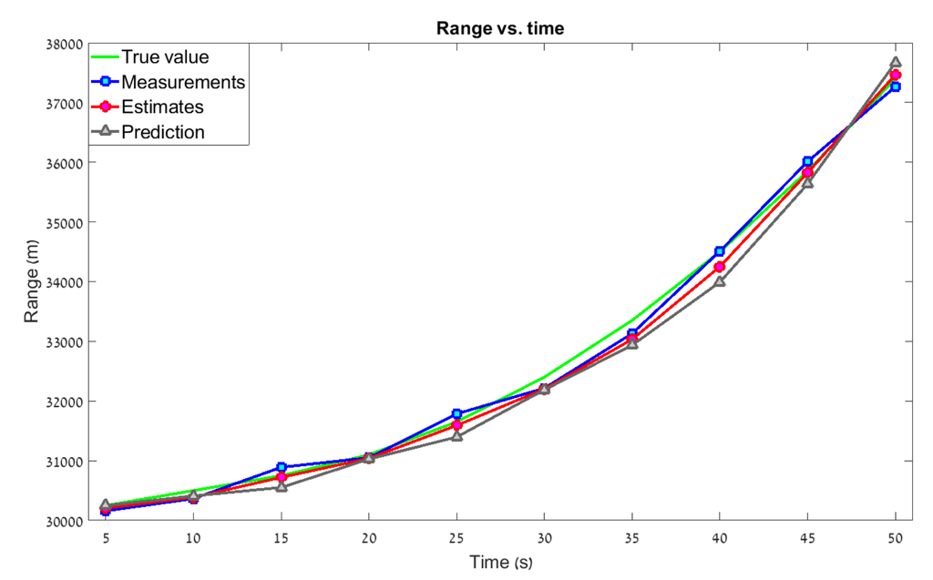

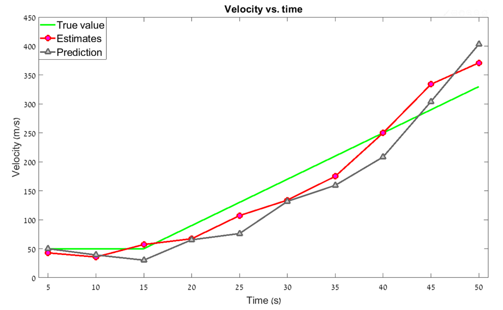

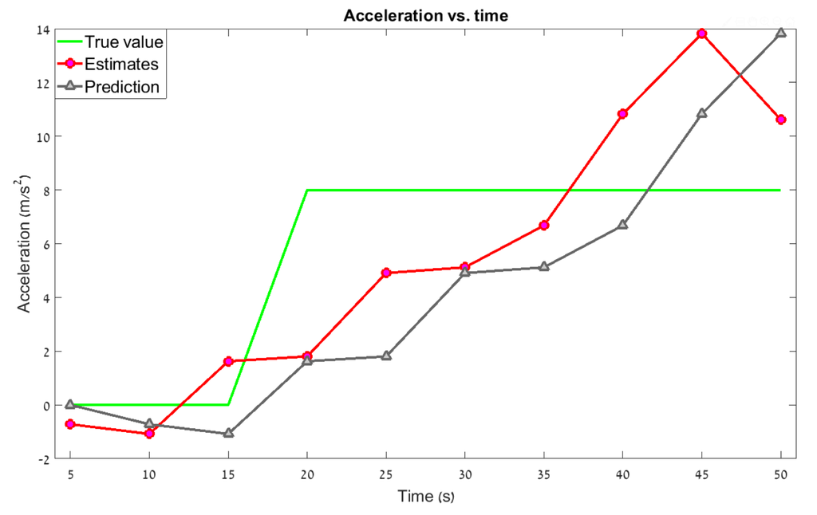

Estimates for range, velocity, and acceleration over many timesteps.

We can see this eliminates the lag error in velocity, but the estimate for acceleration is terrible. If we care about predicting the acceleration, we can add a fourth equation to account for jerk, which will improve the acceleration plot. We can do this type of thing until all the variables we care about are accurately tracked and predicted, which usually will not go beyond position, velocity, and perhaps acceleration.

Some examples of $\alpha$ - $\beta$ - $\gamma$ filters include the *Kalman Filter*, *Extended Kalman Filter*, *Unscented Kalman Filter*, *Cubature Kalman Filter*, *Particle Filter*, and *Bayes Filter*.

## 1D Kalman Filter w/o Process Noise

### Measurement and Estimate Uncertainties

We will begin to include uncertainties in our calculations.

The difference between a measurement and the true value (such as when weighing a gold bar in our first example) is called a *measurement error*. These errors are random, and can be described by a Gaussian with variance $\sigma^2$. This variance of the measurement errors is called the *measurement uncertainty* and is also denoted by $r$. This value can be obtained from the measurement device’s manufacturer or derived via calibration.
$$r = \sigma_{meas}^2$$

The difference between the estimate and the true value is called an *estimate error*. This error becomes smaller as we take more measurements, tending towards zero as the estimates converge on the true value. We don’t know this value, but we can estimate the *uncertainty in estimate*, denoted by $p$.

### The Kalman Gain Equation in 1D

The $\alpha$ - $\beta$ (- $\gamma$) parameters can be calculated dynamically for each filter iteration. These are called the *Kalman Gain*, denoted by $K_n$. The *Kalman Gain Equation* is the third *Kalman Filter* equation we have seen thus far:

$$K_n = \frac{\textrm{Uncertainty in Estimate}}{\textrm{Uncertainty in Estimate + Uncertainty in Measurement}} \\
= \frac{p_{n,n-1}}{p_{n,n-1} + r_n}$$
where:

- $p_{n,n-1}$ is the extrapolated estimate uncertainty
- $r_n$ is the measurement uncertainty
- $0 \leq K_n \leq 1$

This brings us back to the generalized form of the *State Update Equation* which we wrote previously:
$$\hat{x}_{n,n} = (K_n) z_n + (1 - K_n) \hat{x}_{n,n-1}$$
This has some effects:

- When the measurement uncertainty is very large compared to the estimate uncertainty, $K_n$ is close to zero, giving very little weight to the measurements.
- When the measurement uncertainty is very small (the measurements are very precise), $K_n$ is close to one, giving a lot of weight to the measurements and very little weight to the estimates.
- When both uncertainties are about even, $K_n$ is close to 0.5.

The *Kalman Gain* tells us how much we want to change the aggregate estimate when given a new measurement.

### The Covariance Update Equation in 1D

We update the estimate uncertainty via the *Covariance Update Equation*:
$$p_{n,n} = (1 - K_n) p_{n,n-1}$$
where:

- $K_n$ is the Kalman Gain
- $p_{n,n-1}$ is the estimate uncertainty that was calculated during the previous filter iteration
- $p_n,n$ is the estimate uncertainty of the current state

Since $K_n \leq 1$, we can see that $p$ gets smaller with each filter iteration. When the measurement uncertainty is higher, it will take longer for $p$ to converge towards zero.

This is the fourth *Kalman Filter* equation.

### The Covariance Extrapolation Equation in 1D

Like state extrapolation, the estimate uncertainty extrapolation is done with the *Dynamic Model* equations. The *Covariance Extrapolation Equation* thus depends on the situation & its *Dynamic Model*. This is the fifth *Kalman Filter Equation*.

For our first example, measuring a gold bar of constant weight with a scale, the *Dynamic Model* is constant, so the *Covariance Extrapolation Equation* would be
$$p_{n+1,n} = p_{n,n}$$
where $p$ is the estimate uncertainty for the weight.

For the second example of radar tracking an aircraft moving linearly at constant velocity, the *Dynamic Model* is
$$\hat{x}_{n+1,n} = \hat{x}_{n,n} + \hat{\dot{x}}_{n,n} \Delta t \\
\hat{\dot{x}}_{n+1,n} = \hat{\dot{x}}_{n,n}$$
so the *Covariance Extrapolation Equation* is
$$p^x_{n+1,n} = p^x_{n,n} + \Delta t^2 * p^v_{n,n} \\
p^v_{n+1,n} = p^v_{n,n}$$
where:

- $p^x$ is the position estimate uncertainty
- $p^v$ is the velocity estimate uncertainty